# Project 1

## Step 1: Open the `sat_scores.csv` file. Investigate the data, and answer the questions below.

##### 1. What does the data describe?

The data describes for each state: the rate that students take the SAT, as well as the average Verbal and Math score.

##### 2. Does the data look complete? Are there any obvious issues with the observations?

The data looks complete though the last row is an average of all states.

## Step 2: Load the data.

##### 4. Load the data into a list of lists

```python
# Numeric and statistics packages:
import numpy as np
import scipy.stats as stats

import csv

# Pandas handles dataset loading and manipulation:
import pandas as pd

# import the plotting functions:
import matplotlib.pyplot as plt
import seaborn as sns

# Setup matplotlib to display in notebook:
%matplotlib inline

#Read in csv file with pandas
scores_pd = pd.read_csv('/Users/anthonysullivan/Sites/GA-DSI/projects/project-1-sat-scores/assets/sat_scores.csv')

#Open and read in csv file with base python
f = open('/Users/anthonysullivan/Sites/GA-DSI/projects/project-1-sat-scores/assets/sat_scores.csv', 'r')
data = f.read()

# Split data and create a list of lists
rows = data.split()
listed = []
for row in rows:
    values = row.split(',')
    listed.append(values)

# Read in data using csv module and create list of lists
sat_scores_path = '/Users/anthonysullivan/Sites/GA-DSI/projects/project-1-sat-scores/assets/sat_scores.csv'

rows_csv = []

with open(sat_scores_path, 'r') as f:
    reader = csv.reader(f)
    for row in reader:
        rows_csv.append(row)
print rows_csv[0]
print rows_csv[1:4]
```

```
['State', 'Rate', 'Verbal', 'Math']
[['CT', '82', '509', '510'], ['NJ', '81', '499', '513'], ['MA', '79', '511', '515']]
```

##### 5. Print the data

```python
# print both versions of the data read in
print scores_pd
print '_'
print listed
print '_'
print rows_csv
```

```
   State  Rate  Verbal  Math
0     CT    82     509   510
1     NJ    81     499   513
2     MA    79     511   515
3     NY    77     495   505
4     NH    72     520   516
5     RI    71     501   499
6     PA    71     500   499
7     VT    69     511   506
8     ME    69     506   500
9     VA    68     510   501
10    DE    67     501   499
11    MD    65     508   510
12    NC    65     493   499
13    GA    63     491   489
```

[output cut: 42 more lines]

##### 6. Extract a list of the labels from the data, and remove them from the data.

```python
# Extract list of labels and remove them from data
header = rows_csv[0]
data = rows_csv[1:]

print header

# Remove 'ALL' row from data
length = len(data)
print length
data = data[0:length - 1]
print data, len(data)

# Remove 'ALL' row from Dataframe
print scores_pd.State.values
scores_pd = scores_pd[scores_pd.State != 'All']
# Alternate method for removing last row of dataframe, 'All'
# print len(scores_pd)
# scores_pd = scores_pd.drop(scores_pd.index[[len(scores_pd)-1,]])
print scores_pd
```

```
['State', 'Rate', 'Verbal', 'Math']
52
[['CT', '82', '509', '510'], ['NJ', '81', '499', '513'], ['MA', '79', '511', '515'], ['NY', '77', '495', '505'], ['NH', '72', '520', '516'], ['RI', '71', '501', '499'], ['PA', '71', '500', '499'], ['VT', '69', '511', '506'], ['ME', '69', '506', '500'], ['VA', '68', '510', '501'], ['DE', '67', '501',…
['CT' 'NJ' 'MA' 'NY' 'NH' 'RI' 'PA' 'VT' 'ME' 'VA' 'DE' 'MD' 'NC' 'GA' 'IN'
 'SC' 'DC' 'OR' 'FL' 'WA' 'TX' 'HI' 'AK' 'CA' 'AZ' 'NV' 'CO' 'OH' 'MT' 'WV'
 'ID' 'TN' 'NM' 'IL' 'KY' 'WY' 'MI' 'MN' 'KS' 'AL' 'NE' 'OK' 'MO' 'LA' 'WI'
 'AR' 'UT' 'IA' 'SD' 'ND' 'MS' 'All']
   State  Rate  Verbal  Math
0     CT    82     509   510
1     NJ    81     499   513
2     MA    79     511   515
3     NY    77     495   505
4     NH    72     520   516
5     RI    71     501   499
6     PA    71     500   499
```

[output cut: 44 more lines]

##### 7. Create a list of State names extracted from the data. (Hint: use the list of labels to index on the State column)

```python
# Extract the State names as variable states
states = [lists[header.index('State')] for lists in data]
print states
print '-'
# Extract State names from pd.dataframe
states_pd = scores_pd.State.values
print states_pd
```

```
['CT', 'NJ', 'MA', 'NY', 'NH', 'RI', 'PA', 'VT', 'ME', 'VA', 'DE', 'MD', 'NC', 'GA', 'IN', 'SC', 'DC', 'OR', 'FL', 'WA', 'TX', 'HI', 'AK', 'CA', 'AZ', 'NV', 'CO', 'OH', 'MT', 'WV', 'ID', 'TN', 'NM', 'IL', 'KY', 'WY', 'MI', 'MN', 'KS', 'AL', 'NE', 'OK', 'MO', 'LA', 'WI', 'AR', 'UT', 'IA', 'SD', 'ND',…
-
['CT' 'NJ' 'MA' 'NY' 'NH' 'RI' 'PA' 'VT' 'ME' 'VA' 'DE' 'MD' 'NC' 'GA' 'IN'
 'SC' 'DC' 'OR' 'FL' 'WA' 'TX' 'HI' 'AK' 'CA' 'AZ' 'NV' 'CO' 'OH' 'MT' 'WV'
 'ID' 'TN' 'NM' 'IL' 'KY' 'WY' 'MI' 'MN' 'KS' 'AL' 'NE' 'OK' 'MO' 'LA' 'WI'
 'AR' 'UT' 'IA' 'SD' 'ND' 'MS']
```

##### 8. Print the types of each column

```python
#Print the type of each column in data
print 'Lists'
print 'State', type([lists[header.index('State')] for lists in data][0])
print 'Rate', type([lists[header.index('Rate')] for lists in data][0])
print 'Verbal', type([lists[header.index('Verbal')] for lists in data][0])
print 'Math', type([lists[header.index('Math')] for lists in data][0])

print '-'

#Set column types (pd) as variables and print data types
print 'Dataframe'
StateType = scores_pd.State.dtype
RateType = scores_pd.Rate.dtype
VerbalType = scores_pd.Verbal.dtype
MathType = scores_pd.Math.dtype

print 'State', StateType
print 'Rate', RateType
print 'Verbal', VerbalType
print 'Math', MathType
```

```
Lists
State <type 'str'>
Rate <type 'str'>
Verbal <type 'str'>
Math <type 'str'>
-
Dataframe
State object
Rate int64
Verbal int64
Math int64
```

##### 9. Do any types need to be reassigned? If so, go ahead and do it.

```python
numerical_data = [[line[0], int(line[1]), int(line[2]), int(line[3])] for line in data]

print(numerical_data[0:5])
```

```
[['CT', 82, 509, 510], ['NJ', 81, 499, 513], ['MA', 79, 511, 515], ['NY', 77, 495, 505], ['NH', 72, 520, 516]]
```

##### 10. Create a dictionary for each column mapping the State to its respective value for that column.

```python
stateRate = {}
for item in numerical_data:
    stateRate.update({item[0]: item[1]})
print 'Rate Dictionary'
print stateRate
print '-'

stateVerbal = {item[0]: item[2] for item in numerical_data}
print 'Verbal Dictionary'
print stateVerbal
print '-'

stateMath = {item[0]: item[3] for item in numerical_data}
print 'Math Dictionary'
print stateMath
```

```
Rate Dictionary
{'WA': 53, 'DE': 67, 'DC': 56, 'WI': 6, 'WV': 18, 'HI': 52, 'FL': 54, 'WY': 11, 'NH': 72, 'NJ': 81, 'NM': 13, 'TX': 53, 'LA': 7, 'NC': 65, 'ND': 4, 'NE': 8, 'TN': 13, 'NY': 77, 'PA': 71, 'RI': 71, 'NV': 33, 'VA': 68, 'CO': 31, 'AK': 51, 'AL': 9, 'AR': 6, 'VT': 69, 'IL': 12, 'GA': 63, 'IN': 60, 'IA':…
-
Verbal Dictionary
{'WA': 527, 'DE': 501, 'DC': 482, 'WI': 584, 'WV': 527, 'HI': 485, 'FL': 498, 'WY': 547, 'NH': 520, 'NJ': 499, 'NM': 551, 'TX': 493, 'LA': 564, 'NC': 493, 'ND': 592, 'NE': 562, 'TN': 562, 'NY': 495, 'PA': 500, 'RI': 501, 'NV': 509, 'VA': 510, 'CO': 539, 'AK': 514, 'AL': 559, 'AR': 562, 'VT': 511, 'I…
-
Math Dictionary
{'WA': 527, 'DE': 499, 'DC': 474, 'WI': 596, 'WV': 512, 'HI': 515, 'FL': 499, 'WY': 545, 'NH': 516, 'NJ': 513, 'NM': 542, 'TX': 499, 'LA': 562, 'NC': 499, 'ND': 599, 'NE': 568, 'TN': 553, 'NY': 505, 'PA': 499, 'RI': 499, 'NV': 515, 'VA': 501, 'CO': 542, 'AK': 510, 'AL': 554, 'AR': 550, 'VT': 506, 'I…
```

##### 11. Create a dictionary with the values for each of the numeric columns

```python
stateData = {item[0]: [item[1], item[2], item[3]] for item in numerical_data}
print stateData
print len(stateData)


# keys=stateData.keys()
# values=stateData.values()
# print keys, values
# print '-'
```

```
{'WA': [53, 527, 527], 'DE': [67, 501, 499], 'DC': [56, 482, 474], 'WI': [6, 584, 596], 'WV': [18, 527, 512], 'HI': [52, 485, 515], 'FL': [54, 498, 499], 'WY': [11, 547, 545], 'NH': [72, 520, 516], 'NJ': [81, 499, 513], 'NM': [13, 551, 542], 'TX': [53, 493, 499], 'LA': [7, 564, 562], 'NC': [65, 493,…
51
```

## Step 3: Describe the data

##### 12. Print the min and max of each column

```python
# Print the min and max values for each column and their corresponding key
print 'Dictionary'
print '-'
min_rate = min(stateRate.itervalues())
minRateState = [k for k, v in stateRate.iteritems() if v == min_rate]
print 'Minimum Rate: ', minRateState, min_rate
print '-'

max_rate = max(stateRate.itervalues())
maxRateState = [k for k, v in stateRate.iteritems() if v == max_rate]
print 'Maximum Rate: ', maxRateState, max_rate
print '-'

min_verbal = min(stateVerbal.itervalues())
minVerbalStates = [k for k, v in stateVerbal.iteritems() if v == min_verbal]
print 'Lowest Verbal Score: ', minVerbalStates, min_verbal
print '-'

max_verbal = max(stateVerbal.itervalues())
maxVerbalStates = [k for k, v in stateVerbal.iteritems() if v == max_verbal]
print 'Highest Verbal Score: ', maxVerbalStates, max_verbal
print '-'

min_math = min(stateMath.itervalues())
minMathStates = [k for k, v in stateMath.iteritems() if v == min_math]
print 'Lowest Math Score: ', minMathStates, min_math
print '-'

max_math = max(stateMath.itervalues())
maxMathStates = [k for k, v in stateMath.iteritems() if v == max_math]
print 'Highest Math Score: ', maxMathStates, max_math
print'-'

#Find min and max values for each column in the pd.Dataframe
print 'Dataframe'
print '-'
minRate = scores_pd.Rate.values.min()
minRateIndex = scores_pd.loc[scores_pd['Rate'].idxmin()]
maxRateState = scores_pd.State.iloc[minRateIndex.name]
print 'Minimum Rate: ', minRate, maxRateState
print '-'

maxRate = scores_pd.Rate.values.max()
maxRateIndex = scores_pd.loc[scores_pd['Rate'].idxmax()]
maxRateState = scores_pd.State.iloc[maxRateIndex.name]
print 'Maximum Rate: ', maxRate, maxRateState
print '-'

minVerbal = scores_pd.Verbal.values.min()
minVerbalState = scores_pd.State.iloc[scores_pd.loc[scores_pd['Verbal'].idxmin()].name]
print 'Lowest Verbal Score: ', minVerbal, minVerbalState
print '-'

maxVerbal = scores_pd.Verbal.values.max()
maxVerbalIndex = scores_pd.loc[scores_pd['Verbal'].idxmax()]
maxVerbalState = scores_pd.State.iloc[scores_pd.loc[scores_pd['Verbal'].idxmax()].name]
print 'Highest Verbal Score: ', maxVerbal, maxVerbalState
print '-'

minMath = scores_pd.Math.values.min()
minMathState = scores_pd.State.iloc[scores_pd.loc[scores_pd['Math'].idxmin()].name]
print 'Lowest Math Score: ', minMath, minMathState
# print minMathIndex
print '-'

maxMath = scores_pd.Math.values.max()
maxMathState = scores_pd.State.iloc[scores_pd.loc[scores_pd['Math'].idxmax()].name]
print 'Highest Math Score: ', maxMath, maxMathState
print '-'
```

```
Dictionary
-
Minimum Rate:  ['ND', 'MS', 'SD'] 4
-
Maximum Rate:  ['CT'] 82
-
Lowest Verbal Score:  ['DC'] 482
-
Highest Verbal Score:  ['IA'] 593
-
Lowest Math Score:  ['OH'] 439
-
Highest Math Score:  ['IA'] 603
-
Dataframe
-
Minimum Rate:  4 SD
-
Maximum Rate:  82 CT
-
Lowest Verbal Score:  482 DC
-
Highest Verbal Score:  593 IA
-
Lowest Math Score:  439 OH
-
Highest Math Score:  603 IA
-
```

##### 13. Write a function using only list comprehensions, no loops, to compute Standard Deviation. Print the Standard Deviation of each numeric column.

```python
# Function definition to calculate standard deviation
def stddev(lister):
    variance = [(i - np.mean(lister)) ** 2 for i in lister]
    variance = np.sum(variance)
    variance = variance / len(lister)
    std = variance**(1/2.0)
    return 'Std Dev', std, 'Var', variance

# Break out each column as list
Rate = stateRate.values()
Verbal = stateVerbal.values()
Math = stateMath.values()
states = stateRate.keys()

# Print Standard Deviation of each column
print 'Rate: ', stddev(Rate)
print 'Rate: ', np.std(Rate), 'numpy'
print 'Verbal: ', stddev(Verbal)
print 'Math: ', stddev(Math)
print '-'

# Dataframe
print 'Dataframe'
Rate2 = scores_pd.Rate.values
print 'Rate Standard Deviation: ', np.std(Rate2)
```

```
Rate:  ('Std Dev', 27.279238676053591, 'Var', 744.15686274509801)
Rate:  27.2792386761 numpy
Verbal:  ('Std Dev', 33.031982684152283, 'Var', 1091.1118800461361)
Math:  ('Std Dev', 35.929873173114082, 'Var', 1290.955786236063)
-
Dataframe
Rate Standard Deviation:  27.2792386761
```

## Step 4: Visualize the data

##### 14. Using MatPlotLib and PyPlot, plot the distribution of the Rate using histograms.

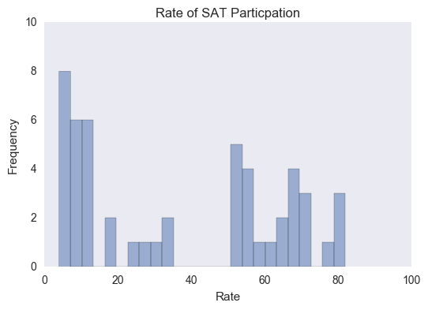

```python
fig, ax = plt.subplots()


plt.hist(Rate, bins=25, alpha=0.5)
# plt.hist(x, 50, normed=1, facecolor='green', alpha=0.75)

plt.xlabel('Rate')
plt.ylabel('Frequency')
plt.title('Rate of SAT Particpation')
plt.axis([0, 100, 0, 10])
plt.grid(False)
```

##### 15. Plot the Math distribution

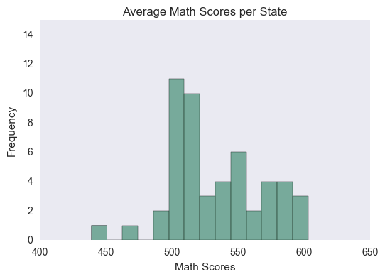

```python
plt.hist(Math, bins=14, alpha=0.5)
plt.xlabel('Math Scores')
plt.ylabel('Frequency')
plt.title('Average Math Scores per State')
plt.axis([400, 650, 0, 15])

scores_pd['Math'].hist(bins=14, alpha=0.5)
plt.grid(False)
plt.show()
```

##### 16. Plot the Verbal distribution

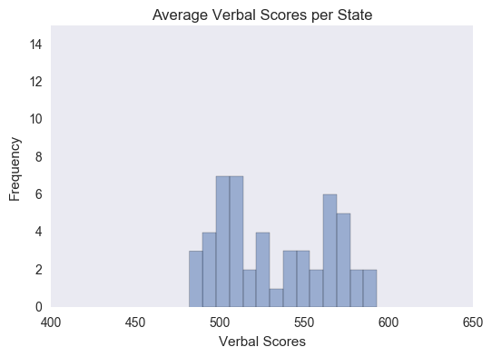

```python
plt.hist(Verbal, bins=14, alpha=0.5)
plt.xlabel('Verbal Scores')
plt.ylabel('Frequency')
plt.title('Average Verbal Scores per State')
plt.axis([400, 650, 0, 15])
plt.grid(False)
```

##### 17. What is the typical assumption for data distribution?

That the data has a normal distribution.

##### 18. Does that distribution hold true for our data?

No

##### 19. Plot some scatterplots. **BONUS**: Use a PyPlot `figure` to present multiple plots at once.

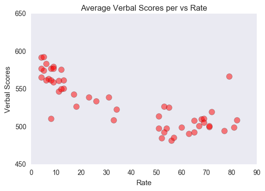

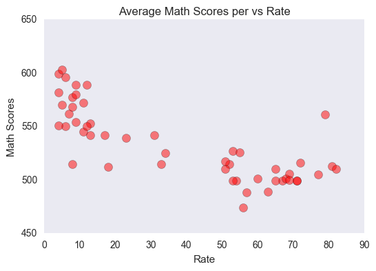

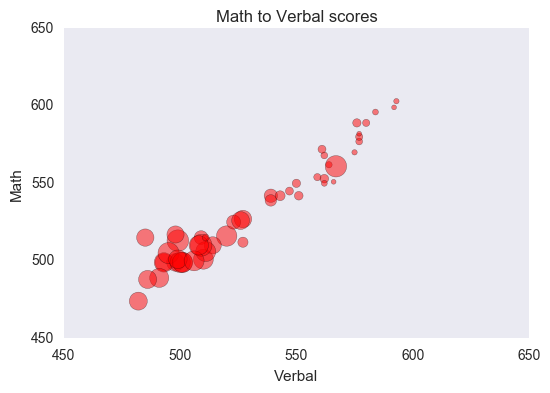

```python
plt.scatter(Rate,Verbal, s=75, c='red', alpha=.5)
plt.xlabel('Rate')
plt.ylabel('Verbal Scores')
plt.title('Average Verbal Scores per vs Rate')
plt.axis([0, 90, 450, 650])
plt.grid(False)
plt.show()

# N = 50
# x = np.random.rand(N)
# y = np.random.rand(N)
# colors = np.random.rand(N)
# area = np.pi * (15 * np.random.rand(N))**2  # 0 to 15 point radii

# plt.scatter(x, y, s=area, c=colors, alpha=0.5)
# plt.show()

plt.scatter(Rate, Math, s=75, c='red', alpha=.5)
plt.xlabel('Rate')
plt.ylabel('Math Scores')
plt.title('Average Math Scores per vs Rate')
plt.axis([0, 90, 450, 650])
plt.grid(False)
plt.show()

area2 = [[item*3] for item in Rate]
plt.scatter(Verbal, Math, s=area2, c='red', alpha=.5)
plt.xlabel('Verbal')
plt.ylabel('Math')
plt.title('Math to Verbal scores')
plt.axis([450, 650, 450, 650])
plt.grid(False)
plt.show()
```

##### 20. Are there any interesting relationships to note?

States with low rates of participation tend to have a higher average score on both the verbal and math sections of the SAT.  
States on the coasts have higher rates of participation. To get a better understanding of this, I would want to look at college matriculation rates and ACT participation rates for each state as well and compare that to SAT data. Also, I want to look at State testing policies for highschool students.

##### 21. Create box plots for each variable.

[figure not shown]

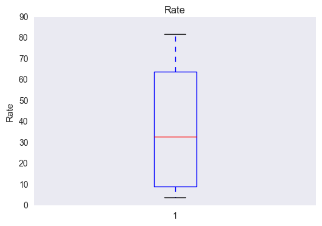

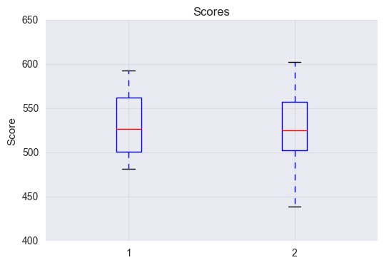

```python
fig, ax1 = plt.subplots(figsize=(4, 5))
fig.canvas.set_window_title('Rate')
plt.subplots_adjust(left=0.075, right=0.95, top=0.9, bottom=0.25)


bp = plt.boxplot(Rate, notch=0, sym='+', vert=1, whis=1.5)
plt.setp(bp['boxes'], color='blue')
plt.setp(bp['whiskers'], color='red')
plt.setp(bp['fliers'], color='red', marker='+')

# Add a horizontal grid to the plot, but make it very light in color
# so we can use it for reading data values but not be distracting
ax1.yaxis.grid(True, linestyle='-', which='major', color='lightgrey', alpha=0.5)

# Hide these grid behind plot objects
ax1.set_axisbelow(True)
ax1.set_title('Comparison of IID Bootstrap Resampling Across Five Distributions')
ax1.set_xlabel('Distribution')
ax1.set_ylabel('Value')

plt.show()

plt.boxplot(Rate)
plt.ylabel('Rate')
plt.title('Rate')
plt.grid(False)
plt.show()

# Plot Verbal and Math scores side by side
score_plots = [Verbal, Math]
plt.boxplot(score_plots)
plt.ylabel('Score')
plt.title('Scores')
# plt.grid(False)
plt.grid(True, linestyle='-', which='major', color='lightgrey',
               alpha=0.5)

plt.show()
```

##### BONUS: Using Tableau, create a heat map for each variable using a map of the US.